# Customer Segmentation For An Airline Carrier Using Clustering

Yurong Fan

2016-10-18

## Understanding the data

| Field | Description |
| --- | --- |
| PNRLocatorID | PNR #. This could,be treated as a confirmation number. Multiple flights and segments all roll,up to one PNR #. |
| TicketNum | Ticket Number - An itinerary may have multiple ticket numbers. |
| CouponSeqNbr | Sabre assigned,sequence number of the ticket coupon. Values are 1-16; values 5 and greater,are a result of a conjunctive ticket. |
| ServiceStartCity | Airport code for,the city the flight is leaving from. |
| ServiceEndCity | Airport code for,the city the flight is landing at. |
| PNRCreateDate | Date the ticket was,booked |
| ServiceStartDate | When the flight,takes off |
| PaxName | First 4 digits of,the passenger last name and the first 2 digits of the passenger 1st name |
| EncryptedName | Passenger name in,encrypted format. |
| GenderCode | M for Male and F,for Female |
| Birthdateid | A unique identifier,that allows you to match birthdates across records without actually providing,the birth date. |
| Age | Age of the,passenger at the time of the flight. |
| PostalCode | Postal code of the,location from where the booking was made. |
| BkdClassOfService | What class of,service (e.g. coach, first class, etc.) the passenger booked |
| TrvldClassOfService | What class of,service (e.g. coach, first class, etc.) the passenger travelled. This could,be upgraded later in the flight. |
| BookingChannel | How the passenger,booked the flight. If this is showing a 3 letter code, it’s most likely booked, at that airport. UFO is booked in Cancun. |
| BaseFareAmt | Amount of the base,fare (without taxes) of all segments on the ticket. Under certain,circumstances such as bulk, net, award tickets, this value will be blank. |
| TotalDocAmt | Total price of this,ticket document including base fare, taxes and fees stated in the,EquivBaseFareCurrCode. In the case of exchanges this amount may be zero or,may only represent the difference in pr… |
| UflyRewardsNumber | The rewards number,that was provided when booked. |
| UflyMemberStatus | The Ufly member,status. It will be either Standard or Elite. |
| CardHolder | True or False value,if the member is also a credit card holder. |
| BookedProduct | Free form text,field that is used to put discount codes in |
| EnrollDate | When the member,enrolled in Ufly rewards |
| MarketingFlightNbr | Flight Number |
| MarketingAirlineCode | The Airlines with,which booking was made. We are only interested in â “SY” which is,the code for Sun Country |
| StopoverCode | O’ for Layovers ie,halt in a city for less than 24 hours.‘X’ for Stopovers that is halt in a,city for more than 24 hours. |

Open the `.csv` data R

```r
folder="E:/.../"
setwd(folder)

data_orig <- data
sample_rows <- sample.int(nrow(data),100000)
data <- data[sample_rows,]
write.csv(data,"data_small.csv")
```

Now look at the structure of the data

```r
str(data)
```

```
## 'data.frame':    100000 obs. of  26 variables:
##  $ PNRLocatorID        : Factor w/ 1179997 levels "AAAACD","AAAAMU",..: 119268 203954 322510 90321 201295 360633 627570 467970 977215 280607 ...
##  $ TicketNum           : num  3.37e+12 3.37e+12 3.37e+12 3.37e+12 3.38e+12 ...
##  $ CouponSeqNbr        : int  1 1 2 1 2 1 1 2 2 1 ...
##  $ ServiceStartCity    : Factor w/ 73 levels "ANC","AZA","BOS",..: 44 44 52 28 32 28 44 44 36 44 ...
##  $ ServiceEndCity      : Factor w/ 80 levels "ABE","ANC","AUS",..: 39 47 52 52 52 52 35 47 52 47 ...
##  $ PNRCreateDate       : Factor w/ 1146 levels "2011-06-22","2011-06-30",..: 525 434 862 1131 834 431 873 743 859 696 ...
##  $ ServiceStartDate    : Factor w/ 730 levels "2013-01-01","2013-01-02",..: 137 61 462 724 506 17 498 335 459 296 ...
##  $ PaxName             : Factor w/ 506327 levels "A ALZI","AABEAL",..: 434243 308876 446773 266610 59273 149276 365316 401508 446896 43546 ...
##  $ EncryptedName       : Factor w/ 1448740 levels "4120414C52484D414E44696420493F7C2067657420746869732072696768745A494144",..: 1256225 893775 1287872 755578 169513 413922 1041741 1162085 1286842 119932 ...
##  $ GenderCode          : Factor w/ 4 levels "","F","M","U": 3 2 3 3 2 3 2 2 3 3 ...
##  $ birthdateid         : int  32591 53055 42936 58342 50136 43280 48149 46986 56168 31682 ...
##  $ Age                 : int  73 17 46 4 26 44 32 34 10 76 ...
##  $ PostalCode          : Factor w/ 8132 levels "","00000","00022",..: 3850 1 1 1 1 1 1 1 1 3930 ...
##  $ BkdClassOfService   : Factor w/ 3 levels "Coach","Discount First Class",..: 3 1 1 1 1 1 1 1 1 1 ...
##  $ TrvldClassOfService : Factor w/ 3 levels "Coach","Discount First Class",..: 3 1 1 1 1 1 1 1 1 1 ...
##  $ BookingChannel      : Factor w/ 29 levels "ANC  ","BOS  ",..: 23 23 27 23 18 18 18 18 27 21 ...
##  $ BaseFareAmt         : num  0 427 0 304 221 ...
##  $ TotalDocAmt         : num  7 481 0 355 260 ...
##  $ UFlyRewardsNumber   : int  201023325 NA NA NA NA NA NA NA NA 200226401 ...
##  $ UflyMemberStatus    : Factor w/ 3 levels "","Elite","Standard": 3 1 1 1 1 1 1 1 1 3 ...
##  $ CardHolder          : Factor w/ 3 levels "","false","true": 3 1 1 1 1 1 1 1 1 2 ...
##  $ BookedProduct       : Factor w/ 396 levels "","03RYPR","04NY4R",..: 337 1 34 289 1 1 1 1 34 1 ...
##  $ EnrollDate          : Factor w/ 192106 levels "","2007-07-17 00:00:00.0000000",..: 25956 1 1 1 1 1 1 1 1 4738 ...
##  $ MarketingFlightNbr  : Factor w/ 819 levels "0001","0003",..: 354 522 755 456 361 456 451 526 763 522 ...
##  $ MarketingAirlineCode: Factor w/ 5 levels "DE","F9","FI",..: 5 5 5 5 5 5 5 5 5 5 ...
##  $ StopoverCode        : Factor w/ 3 levels "","O","X": 1 1 2 1 2 1 1 3 2 1 ...
```

and summarize it

```r
summary(data)
```

```
##   PNRLocatorID     TicketNum          CouponSeqNbr   ServiceStartCity
##  OPKWDG :   25   Min.   :3.372e+12   Min.   :1.000   MSP    :46964
##  DILBDW :   19   1st Qu.:3.372e+12   1st Qu.:1.000   LAS    : 5161
##  RHBKZU :   17   Median :3.372e+12   Median :1.000   JFK    : 4084
##  EJYFAM :   16   Mean   :3.374e+12   Mean   :1.461   MCO    : 3997
##  LQBDYD :   15   3rd Qu.:3.377e+12   3rd Qu.:2.000   LAX    : 3860
##  DXCIJF :   14   Max.   :3.380e+12   Max.   :6.000   SFO    : 3749
##  (Other):99894                                       (Other):32185
##  ServiceEndCity     PNRCreateDate     ServiceStartDate    PaxName
##  MSP    :46762   2013-12-03:  429   2013-12-01:  279   JOHNMA :   79
##  LAS    : 5133   2013-12-02:  421   2014-11-30:  265   JOHNDA :   47
##  MCO    : 4037   2012-11-26:  349   2014-12-28:  261   JOHNBR :   44
##  JFK    : 3936   2013-12-04:  321   2014-02-16:  258   JOHNKA :   43
##  LAX    : 3857   2014-01-06:  310   2014-03-16:  254   JOHNJA :   40
##  SFO    : 3826   2014-09-09:  307   2013-12-26:  253   JOHNJE :   38
##  (Other):32449   (Other)   :97863   (Other)   :98430   (Other):99709
##                                                                     EncryptedName
##  4A4F484E534F4E44696420493F7C2067657420746869732072696768744A454E4E49464552:    6
##  4A4F484E534F4E44696420493F7C2067657420746869732072696768744D415454484557  :    6
##  414E444552534F4E44696420493F7C2067657420746869732072696768744A414D4553    :    5
##  44495454455244696420493F7C2067657420746869732072696768744D41524B204E      :    5
##  44554E43414E44696420493F7C206765742074686973207269676874414D59            :    5
##  475245494E4B4544696420493F7C20676574207468697320726967687452494348415244  :    5
##  (Other)                                                                   :99968
##  GenderCode  birthdateid           Age             PostalCode
##   : 1325    Min.   :-287831   Min.   :-2883.00          :79885
##  F:51258    1st Qu.:  39620   1st Qu.:   26.00   55416  :  262
##  M:47414    Median :  45029   Median :   40.00   55311  :  257
##  U:    3    Mean   :  44986   Mean   :   40.04   55347  :  256
##             3rd Qu.:  50237   3rd Qu.:   55.00   55044  :  227
##             Max.   :1112840   Max.   :  951.00   55124  :  209
##             NA's   :1325      NA's   :1325       (Other):18904
##             BkdClassOfService           TrvldClassOfService
##  Coach               :97237   Coach               :92520
##  Discount First Class:   36   Discount First Class: 2607
##  First Class         : 2727   First Class         : 4873
##
##
##
##
```

[output cut: 17 more lines]

```
##                             :79793   341    : 2804
##  2007-07-17 00:00:00.0000000:  625   342    : 2545
##  2007-12-02 15:27:19.0000000:   23   504    : 2226
##  2007-12-02 15:06:38.0000000:   14   503    : 2155
##  2013-01-23 15:53:24.0000000:    9   244    : 2099
##  2011-03-03 06:31:17.0000000:    7   243    : 1977
##  (Other)                    :19529   (Other):86194
##  MarketingAirlineCode StopoverCode
##  DE:    0              :50195
##  F9:   86             O:46606
##  FI:    1             X: 3199
##  HA:   45
##  SY:99868
##
##
```

## Data Preperation

### Data Cleaning

The following are the attributes that need treatment.

| GenderCode and Birthdateid | Remove rows with faulty Gendercode and BirthdateID |
| --- | --- |
| Age | Replace faulty values with median value |
| UflyRewardsNumber | Replace NAs with 0 |
| UflyMemberStatus | Replace Missing values with “non-member” |
| Duplicate PNRs | Remove rows with duplicate PNRs |
| BookingChannel | Remove rows with city codes as BookingChannel |
| Marketing Airline Code | Remove rows with airline code other than “SY” |
| Error PNRs | Remove error PNRs |

We need to remove rows with faulty Gendercode and BirthdateID

```r
#Filtering out records which have NA for BirthdateID
#same as data <- data %>%filter(!is.na(birthdateid))
data%<>%filter(!is.na(birthdateid))

data$GenderCode<-as.character(data$GenderCode)
data%<>%filter(GenderCode!="")

#Filtering out records which have ââ for GenderCode
data$GenderCode<-as.factor(data$GenderCode)
```

Replace faulty values in Age with median value

```r
#Replacing negative ages with median value
data$Age[data$Age < 0] <- median(data$Age)

#Replacing age values greater than 120 with median value
data$Age[data$Age > 120] <- median(data$Age)
```

Replace NAs in UflyRewardsNumber with 0

```r
#Replace NAs with 0
data$UFlyRewardsNumber[is.na(data$UFlyRewardsNumber)] <- 0
```

Replace Missing values in UflyMemberStatus with ânon-memberâ

```r
#Convert factor level data to string
data$UflyMemberStatus<-as.character(data$UflyMemberStatus)

#Replace missing values with ânon-uflyâ
data$UflyMemberStatus[data$UflyMemberStatus==''] <-"non-ufly"
```

Retaining only those rows which have single occurrence of PNRLocatorID, CouponSeqNbr, PaxName, ServiceStartCity, ServiceEndCity, ServiceStartDate combination.

```r
data%<>%
  group_by(PNRLocatorID,CouponSeqNbr,PaxName,ServiceStartCity,ServiceEndCity,ServiceStartDate)%>%
  filter(n()==1)
```

Remove rows with faulty city codes as BookingChannel. Some rows have city names for Booking Channel. Replacing faulty data with âOtherâ

```r
data$BookingChannel<-as.character(data$BookingChannel)
data$BookingChannel[data$BookingChannel!="Outside Booking" &
                      data$BookingChannel!="SCA Website Booking" &
                      data$BookingChannel!="Tour Operator Portal" &
                      data$BookingChannel!="Reservations Booking" &
                      data$BookingChannel!="SY Vacation"] <- "Other"
data$BookingChannel<-as.factor(data$BookingChannel)
```

Remove rows with MarketingAirlineCode code other than âSYâ, the airline code for Sun Country.

```r
data$MarketingAirlineCode<-as.character(data$MarketingAirlineCode)
data%<>%filter(MarketingAirlineCode=="SY")
data$MarketingAirlineCode<-as.factor(data$MarketingAirlineCode)
```

Creating a new column called error which contains 1 if the PNR is errored or 0 otehrwise. Error PNR refers to those which do not start with coupon sequence number 1.

```r
data%<>%group_by(PNRLocatorID)%>%
  mutate(error= ifelse(min(CouponSeqNbr)!=1,1,0))
```

Retaining only the non errored rows and check how many rows are remaining.

```r
data%<>%filter(error==0)
nrow(data)
```

```
## [1] 59571
```

### Data Sampling

```r
#Obtain Unique PNRs
uniquePNRs<-unique(data$PNRLocatorID)

#To produce the same samples every time the code is run
set.seed(1234567)


sample_PNRs<-sample(uniquePNRs,10000)

#Obtaining data related to the sampled 10,000 PNRs
sample_data<-data%>%filter(PNRLocatorID %in% sample_PNRs)
```

### Data Transformation

For the purpose of analysis, attributes are created as a combination of other attributes.

[output not shown]

First, create a Unique ID for each customer by concatenating Encrypted name, GenderCode and birthdateid.

```r
sample_data<-sample_data%>% mutate(uid=paste(EncryptedName,GenderCode,birthdateid,sep=""))
```

Next, we bin the customers’ age into 1 of 5 age buckets

```r
sample_data%<>%mutate(age_group =
                        ifelse(Age>=0 & Age<18,"0-17",
                               ifelse(Age>=18 & Age < 25,"18-24",
                                      ifelse(Age>=25&Age<35,"25-34",
                                             ifelse(Age>=35 & Age<55,"35-54",
                                                    ifelse(Age>=55,"55+",0)
                                                    )
                                             )
                                      )
                               )
                    )
```

Next, we determining the true Service Start City for each row in the data. It will be the First city from which the trip started

```r
true_origins<-sample_data%>%
  arrange(PNRLocatorID,CouponSeqNbr)%>%
  group_by(PNRLocatorID,PaxName)%>%
  do(data.frame(true_origin=first(.$ServiceStartCity)))

sample_data<-merge(sample_data,true_origins,
                   by.x=c("PNRLocatorID","PaxName"),
                   by.y = c("PNRLocatorID","PaxName"))
```

Next, we determine where the trip ended. If the trip is a round trip, the service end city (Final Destination) will be the same as the service start city (True Origin)

```r
final_destination<-sample_data%>%
  arrange(PNRLocatorID,CouponSeqNbr)%>%
  group_by(PNRLocatorID,PaxName)%>%
  do(data.frame(final_destination=last(.$ServiceEndCity)))

sample_data<-merge(sample_data,final_destination,
                   by.x=c("PNRLocatorID","PaxName"),
                   by.y = c("PNRLocatorID","PaxName"))
```

Next, we determine what was the trips true destination. We assume this was the place where most time was spent on the trip.

```r
#Convert Service Start date to Date type
sample_data$ServiceStartDate<-as.Date(sample_data$ServiceStartDate)

#The place of maximum stay during the trip.
diff1<-sample_data%>%
  arrange(PNRLocatorID,CouponSeqNbr)%>%
  group_by(PNRLocatorID,PaxName)%>%
  mutate(stay=lead(ServiceStartDate)-ServiceStartDate,default=0)%>%
  select(PNRLocatorID,PaxName,ServiceStartCity,ServiceEndCity,ServiceStartDate,stay)

diff1$stay[is.na(diff1$stay)]<-0
diff1$stay<-as.numeric(diff1$stay)

true_destination<-diff1%>%
  group_by(PNRLocatorID,PaxName)%>%
  do(data.frame(true_destination= first(as.character(.$ServiceEndCity)[.$stay==max(.$stay)])))
sample_data<-merge(sample_data,true_destination,
                   by.x=c("PNRLocatorID","PaxName"),
                   by.y = c("PNRLocatorID","PaxName"))
```

Next, we determine if the trip was a one-way or round-trip. The trip is considered a round trip if the service end city (Final Destination) will be the same as the service start city (True Origin).

```r
sample_data%<>%
  mutate(round_trip = ifelse(as.character(true_origin)==as.character(final_destination), 1, 0))
```

Next, we determine the group size, the number of people who traveled together in each trip.

```r
sample_data%<>%
  group_by(PNRLocatorID)%>%
  mutate(group_size= length(unique(uid)))
```

Next, we have a special inidcator if the group-size was 1,i.e., flown by a single customer

```r
sample_data%<>%
  group_by(PNRLocatorID)%>%
  mutate(group= ifelse(group_size>1,1,0))
```

Next, handle seasonality in terms of quaters. Assign Q1 to Q4 based on the quarter of the year in which the trip was made

```r
sample_data$ServiceStartDate<-as.Date(sample_data$ServiceStartDate)
#Convert ServiceStartDate from factor to Date format
sample_data%<>%
  group_by(PNRLocatorID,PaxName)%>%
  mutate(seasonality= ifelse(month(ServiceStartDate)>=1 & month(ServiceStartDate)<=3,"Q1",
                             ifelse(month(ServiceStartDate)>=4 & month(ServiceStartDate)<=6,"Q2",
                                    ifelse(month(ServiceStartDate)>=7 & month(ServiceStartDate)<=9,"Q3",
                                           ifelse(month(ServiceStartDate)>=10 & month(ServiceStartDate)<=12,"Q4",0)
                                           )
                                    )
                             )
         )
```

Finally, we calculate the number of days the ticket was booked in advance. It is the difference between PNRCreateDate and ServiceStartDate

```r
sample_data$PNRCreateDate <- as.Date(sample_data$PNRCreateDate)
sample_data$ServiceStartDate <- as.Date(sample_data$ServiceStartDate)
sample_data%<>%
  mutate(days_pre_booked=as.numeric(floor( difftime(ServiceStartDate,
                                                    PNRCreateDate,units=c("days")))))
```

## Customer Segmentation

We want to use the data to segment customers of Sun Country Airlines into general categories of people with similar flying patterns. The goal is to group the observations in the data into clusters such that every datum in a cluster is more similar to other datums in the same cluster than it is to datums in other clusters.

### Change data granularity

In order to run the segmentation algorithm, we need to first have the data at the right granularity. Since we are looking to segment customers, it is important to bring the data to the granularity of customers. We transform the data such that each row represents a unique customer-PNR combination.

```r
sample_data%<>%
  select(PNRLocatorID, uid, PaxName, ServiceStartDate, BookingChannel, TotalDocAmt,
         UFlyRewardsNumber,UflyMemberStatus, age_group,true_origin,true_destination,
         round_trip,group_size,group, seasonality,days_pre_booked)

#This may take a considerable amount of time
customer_data<-sample_data%>%
  group_by(PNRLocatorID,uid)%>%
  summarise(PaxName=unique(PaxName),
            ServiceStartDate=first(ServiceStartDate),
            BookingChannel=first(BookingChannel),
            avg_amt=max(TotalDocAmt),
            UFlyRewards=first(UFlyRewardsNumber),
            UflyMemberStatus=first(UflyMemberStatus),
            age_group=last(age_group),
            true_origin=first(true_origin),
            true_destination=first(true_destination),
            round_trip=first(round_trip),
            group_size=first(group_size),
            group=first(group),
            seasonality=last(seasonality),
            days_pre_booked=max(days_pre_booked))

#Retaining only those attributes that are meaningful for clustering
customer_data%<>%
  select(-PNRLocatorID,-uid,-PaxName,-ServiceStartDate,-UFlyRewards)
  nrow(sample_data)
```

```
## [1] 10886
```

```r
  #Granularity of data was reduced to customer level
  nrow(customer_data)
```

```
## [1] 10654
```

### Units and Scaling

The initial understanding of the data has shown us that this contains attributes of different units. Units affect what clustering algorithms will discover. One way to try to make the clustering more coordinate- free is to transform all the columns to have a value between 0 and 1. This is called Normalization. There are multiple techniques of achieving normalization. We will be using the min-max normalization technique.

```r
#Min-Max normalization: x= x-max/max-min
normalize <- function(x){return ((x - min(x))/(max(x) - min(x)))}

temp<- ungroup(customer_data)

customer_data_km = mutate(temp,
                     avg_amt = normalize(avg_amt),
                     days_pre_booked = normalize(days_pre_booked),
                     group_size=normalize(group_size))
```

### Clustering algorithm

**Various clustering algorithms can be used to achieve the goal of segmentation.**

**Hierarchical clustering doesn’t need to set the number of clusters in advance but is compuational expensive for large data sets.Considering the client may further apply the model to larger datasets in the future, I will not use it as the final clustering model but will use it to explore the optimal number of clusters.**

**K-means is the most popular partitional clustering method however is not feasible for non-numerical data or mixed data which is the nature of the data for this project. K-prototype is a extension of k-means for mixed data types which also inherites computational efficiency from k-means. Although nominal data can be converted into binary data in order to use k-means, this method will dramatically increase dimensions of the data.**

**Another partitional method Gaussian Mixture Model can assign each data point a membership probability for different clusters however can only process numerical data.**

**Thus, I will use k-prototype as the clustering model.**

> converting categorical variables to factors

```r
#convert all categorical varaibles to factors
customer_data_km$BookingChannel <- as.factor(customer_data_km$BookingChannel)
customer_data_km$UflyMemberStatus <- as.factor(customer_data_km$UflyMemberStatus)
customer_data_km$age_group <- as.factor(customer_data_km$age_group)
customer_data_km$true_origin <- as.factor(customer_data_km$true_origin)
customer_data_km$true_destination <- as.factor(customer_data_km$true_destination)
customer_data_km$round_trip <-as.factor(customer_data_km$round_trip)
customer_data_km$group <- as.factor(customer_data_km$group)
customer_data_km$seasonality <-as.factor(customer_data_km$seasonality)
#convert customer_data_km to data frame
customer_data_km <- data.frame(customer_data_km)
```

> Selecting optimal number of clusters

#### Using Hierarchical clustering to explore optimal number of clusters

```r
#hierarchical clustering
##install.packages("cluster")
library(cluster)
```

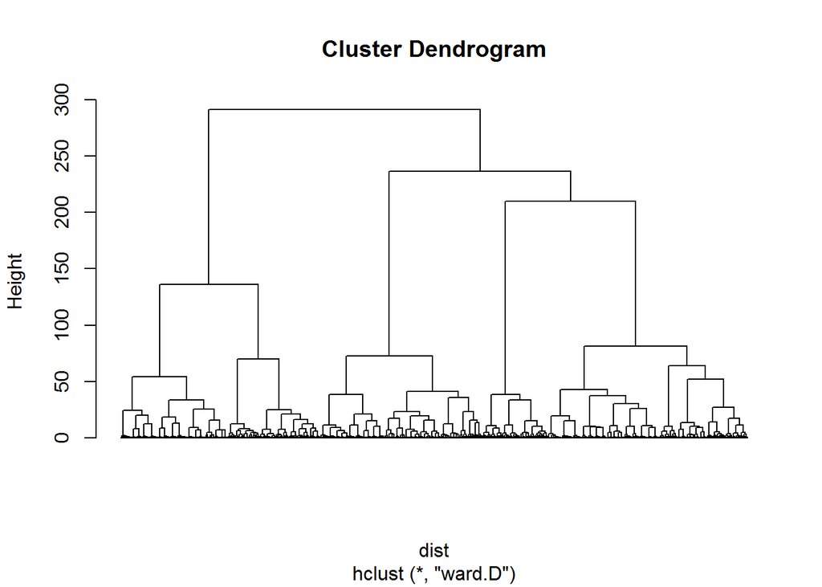

```r
dist <- daisy(customer_data_km[,2:12], metric = "gower")
library(stats)
hcluster <- hclust(dist, method = "ward.D")
plot(hcluster, hang = 0, label = F, main = "Cluster Dendrogram")
```

**The dendrogram generated by hierarchical clustering suggests 4 or 5 are ideal number of clusters.**

#### Ploting elbow curve and silhouette curve for k-prototype

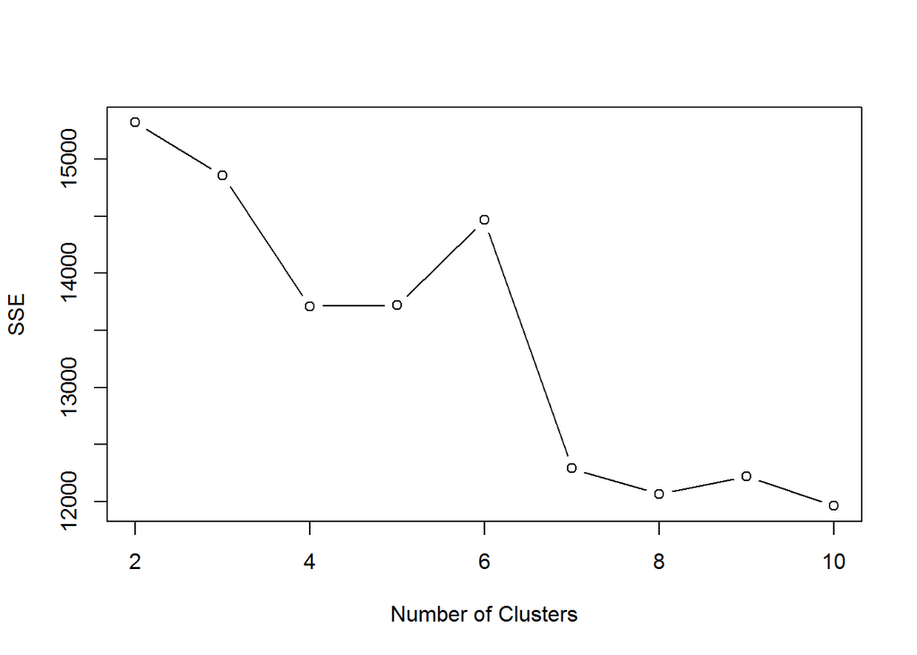

```r
SSE_curve <- c()
sil_curve <- c()
for (n in 2:10) {
  kcluster <- kproto(customer_data_km[,2:12], n, lambda = 0.5)
  sse <- sum(kcluster$withinss)
  SSE_curve[n-1] <- sse
  sil <- silhouette(kcluster$cluster, dist(customer_data_km[,2:12]))
  sil_curve[n-1] <- mean(sil[,3])
}

plot(2:10, SSE_curve, type="b", xlab="Number of Clusters", ylab="SSE")
```

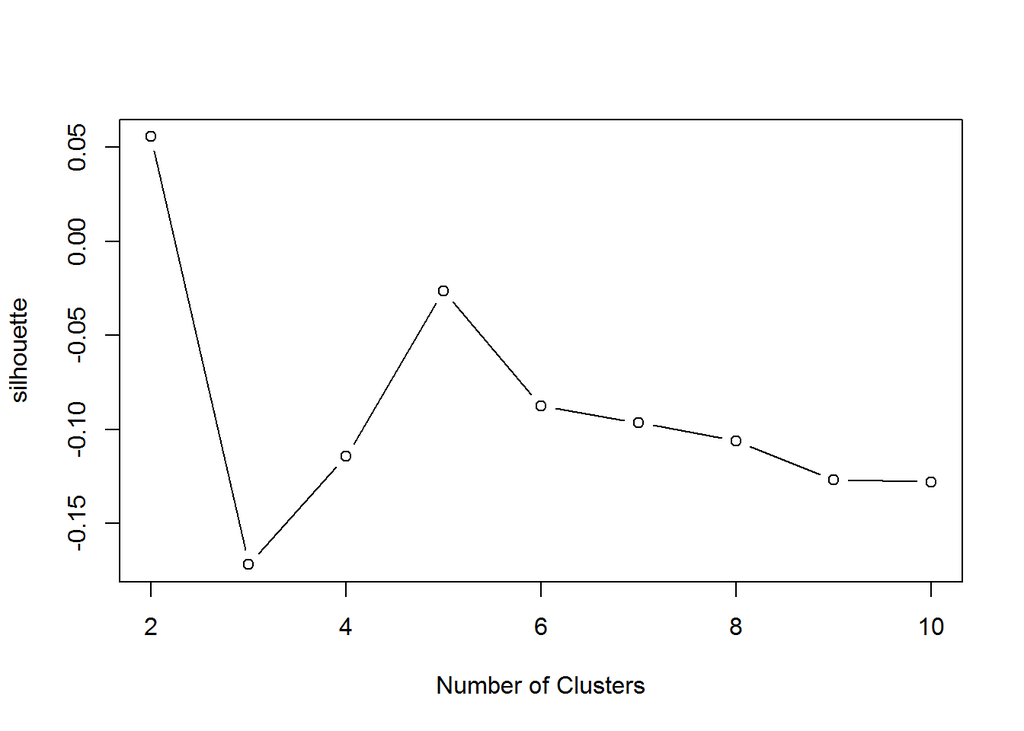

```r
plot(2:10, sil_curve, type="b", xlab="Number of Clusters", ylab="silhouette")
```

> Performing clustering

```r
#Perform 5 clusters k-prototype, remove PNRLocatorID from the data
kcluster5 <- kproto(customer_data_km[,2:12], 5,lambda = 0.5)
#get sizes of each cluster
kcluster5$size
```

```
## clusters
##    1    2    3    4    5
## 2996 2444  656 2562 1996
```

### Visualizing the Clusters

Now that the data is divided into clusters, we can interpret the clusters by summarizing the data within each cluster. The most intuitive way of interpreting clusters is using visualizations. **I grouped all variables into 3 groups - customer profile related, booking related.**

> Differences of customer profileS among segments

I first plotted the differences between clusters for customer profile related variables including age_group and UflyMemberStatus as below.

#### age group

**The first graph which plots the proportion of each age group in each cluster shows that cluster4 contains the largest proportion of customers above 55 years old cross clusters, while cluster1 contains the largest proportion of younger customers below 34 years old. Cluster2 and Cluster5 have similar distribution over age groups while Cluster3 has a more even mixture of all age groups.**

#### Ufly membership

**From second graph which plots the proprotion of each type of Ufly membership in each cluster, we can find the Ufly membership stutas itself cannot clearly associated one customer with one probable customer segement and corresponding behaviors.**

#### age group and Ufly membership

**The third graph conbines the two variable agains each cluster to show their interactive relationship in different clusters. And count instead of proportion is used here. From this graph, we can further find that Cluster4 has the most number of Ufly members most of whom are above 55 years old. Cluster2 contains the second largest number of Ufly members most of whom are 35-54 years old.**

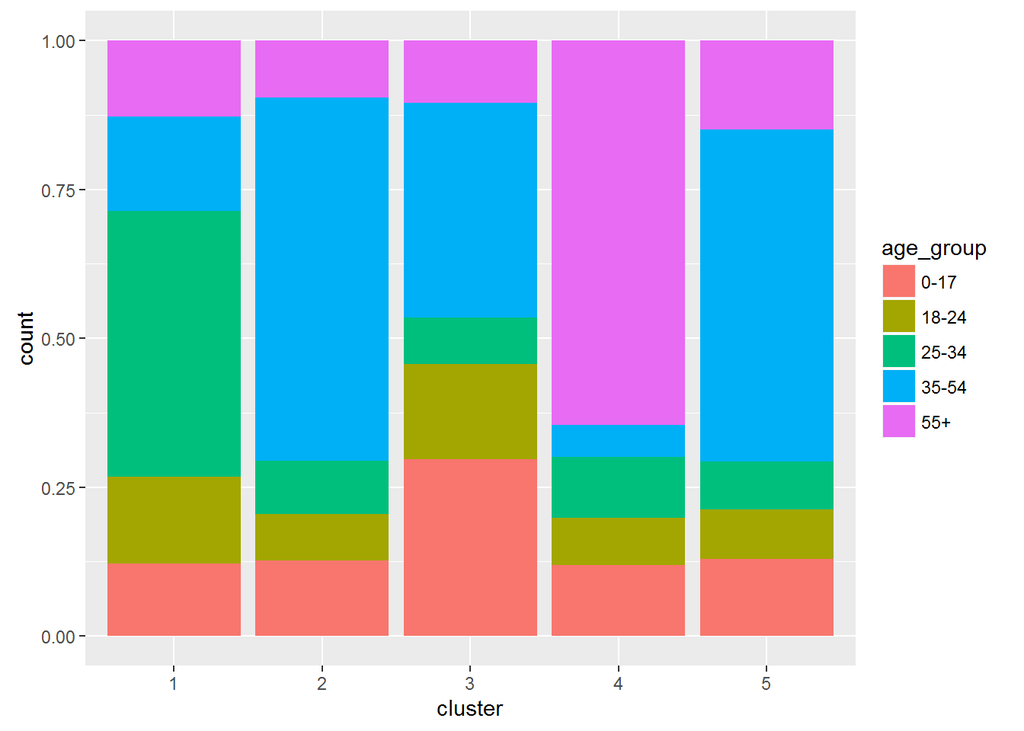

```r
library(ggplot2)
library(gridExtra)
#combine clustering result into the original data
cluster <- as.factor(kcluster5$cluster)
customer_data_cluster <- cbind(customer_data_km,cluster)

#customer profile
ggplot(customer_data_cluster,aes(x=cluster,fill=age_group))+geom_bar(position = 'fill')
```

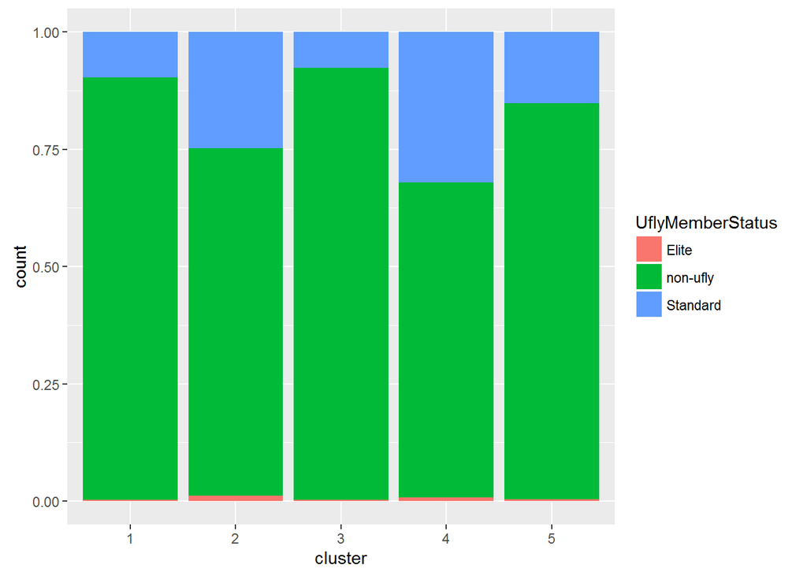

```r
ggplot(customer_data_cluster,aes(x=cluster,fill=UflyMemberStatus))+geom_bar(position = 'fill')
```

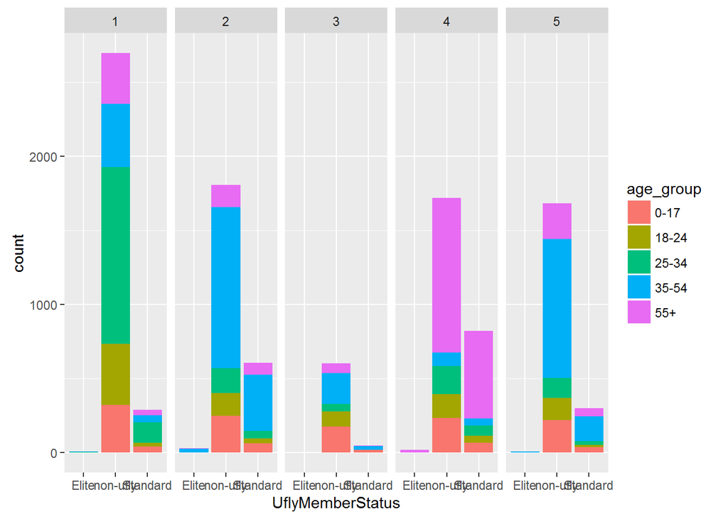

```r
ggplot(customer_data_cluster,aes(x=UflyMemberStatus,fill=age_group))+geom_bar(position = 'stack') + facet_grid(.~cluster)
```

> Differences of booking behaviors among customer segments

I then visualized the differences between clusters in terms of booking related variables including BookingChannel, days_pre_booked, and avg_amt in below 3 grahps.Now the differences between Cluster2 and Cluster5 are uncovered and we can also find the uniqueness of Cluster3.

** Uniqueness of Cluster3: **+** Customers in Cluster3 tend to have unique booking behaviors. Most customers in Cluster3 use Reservation Booking while no other cluster has the similar pattern. And they tend to book fights far ahead of travel which is also unique cross clusters.**

** More insights among the other Clusters:**

- **Interestingly, the eldest age group whom are majorly groupped into Cluster4 use SCA website most for booking which can probabliy indicate that the eldest age group is more loyal to Sun Country.**
- **Cluster1 which mainly contains younger customers (below 34 years old) has the lowest average of days_pre_booked probabliy because younger customers are less planned and prone to spontaneous travel.**

#### Avg_amt:

Similarly to Ufly membership status, the Avg_amt is not a differentiator among clusters.

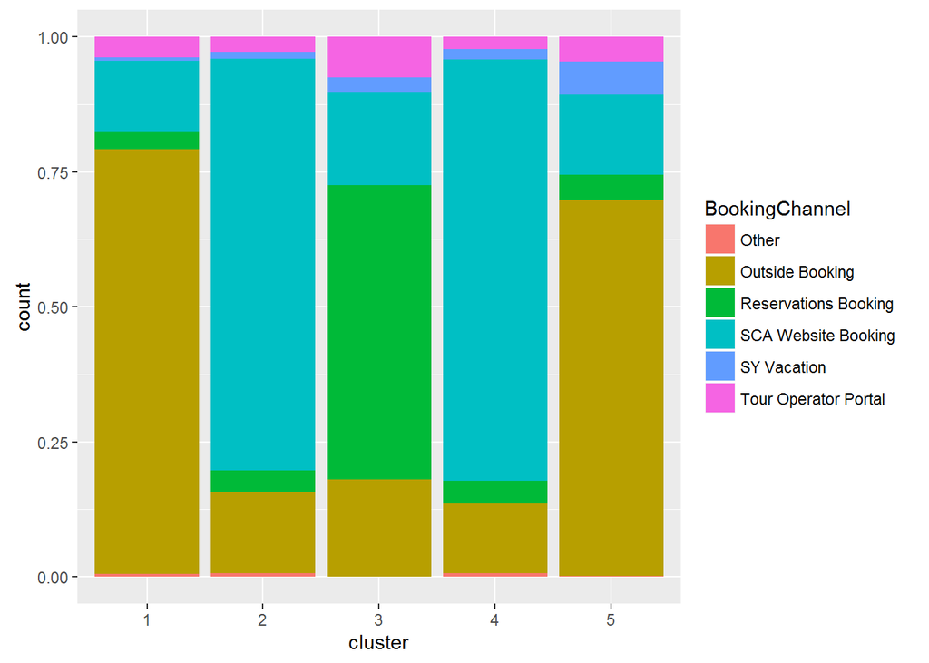

```r
ggplot(customer_data_cluster,aes(x=cluster,fill=BookingChannel))+geom_bar(position = 'fill')
```

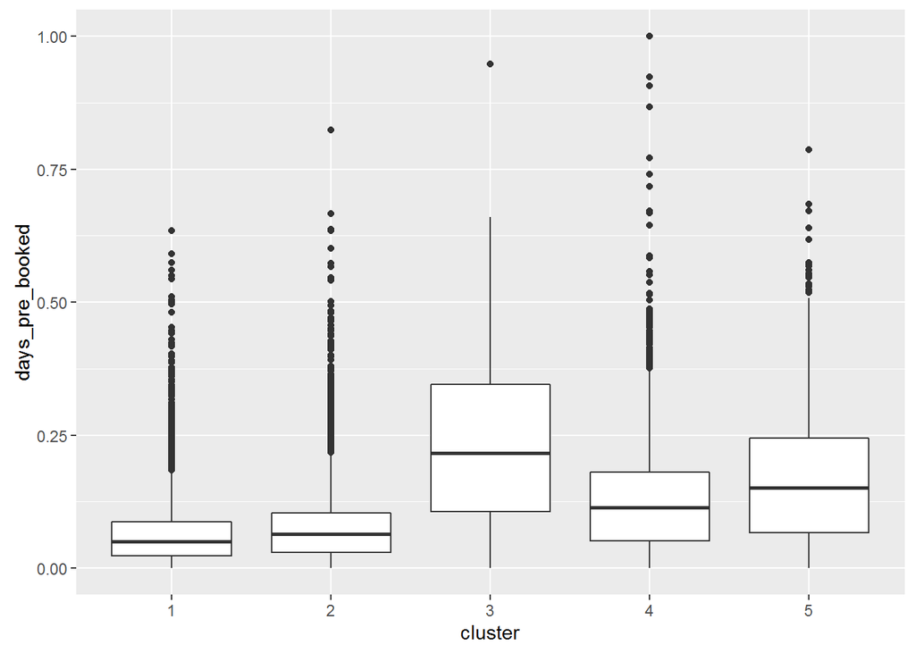

```r
ggplot(customer_data_cluster,aes(x=cluster,y=days_pre_booked))+geom_boxplot()
```

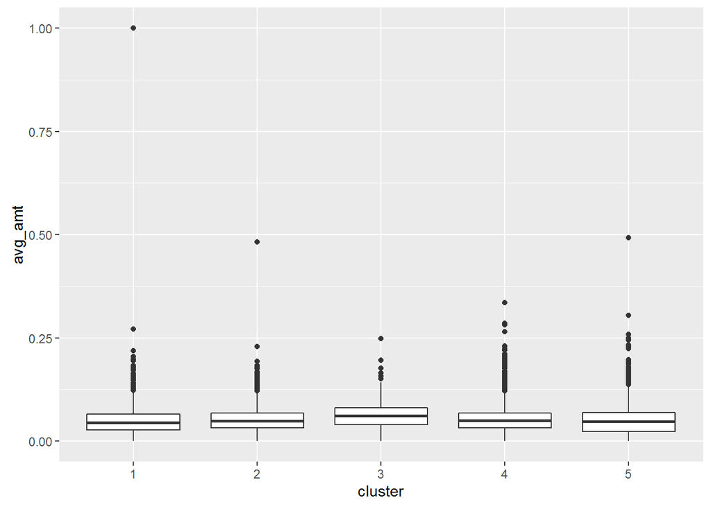

```r
ggplot(customer_data_cluster,aes(x=cluster,y=avg_amt))+geom_boxplot()
```

Differences of trip patterns among customers segments

Below graphs plotted trip related attributes for each cluster from which we can find more differences.

#### seasonality

**Not all segments of customers tend to choose winter for travel to escape the cold weather in Minnesota.**

**While younger customers in Cluster1 prefer to travel during Q3. And customers in Cluster2 and Cluster5 most of whom are 35-54 years old tend to travel in Q2 and Q1 respectively.**

#### round trip

**Unfortunately, round trip only constitutes less than 5% in all Clusters and it is not a differentiator for sgementation.**

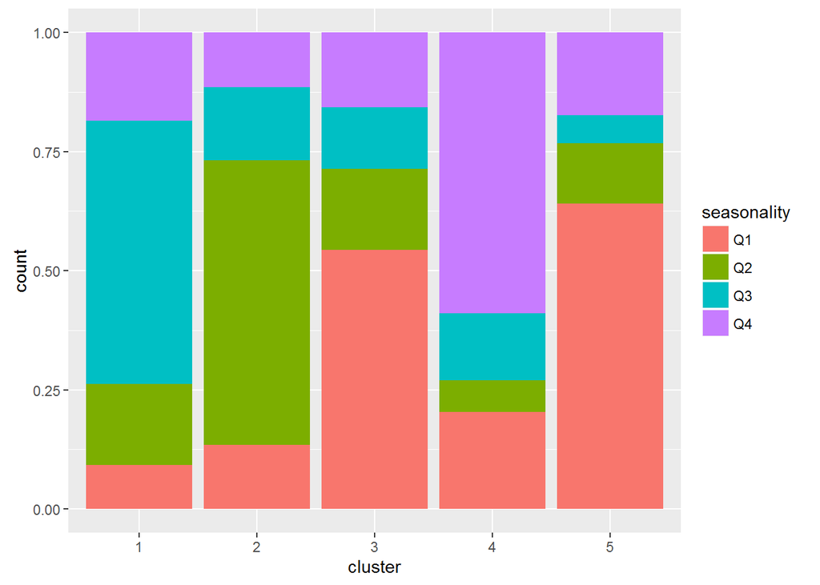

```r
ggplot(customer_data_cluster,aes(x=cluster,fill=seasonality))+geom_bar(position = 'fill')
```

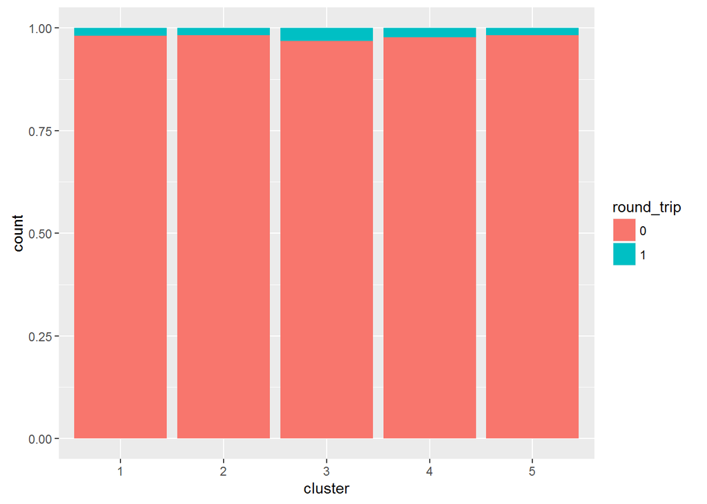

```r
ggplot(customer_data_cluster,aes(x=cluster,fill=round_trip))+geom_bar(position = 'fill')
```

#### Origin and destination

**Since there are more than 50 different origins or destinations, in order to generate an clear visualization, only the most frequent origins and destinations will be labeled separately in the visualization. All the others are grouped as “Others”.**  
**Investigate the most frequent origins and destinations**

```r
#top origins
top_origin <- group_by(customer_data_cluster, true_origin)%>%
  summarise(count= n(), pct = round(n()/nrow(customer_data_cluster),2))%>%
  arrange(desc(count))%>%
  head(10)
top_origin
```

```
## # A tibble: 10 x 3
##    true_origin count   pct
##         <fctr> <int> <dbl>
## 1          MSP  6499  0.61
## 2          DFW   471  0.04
## 3          JFK   454  0.04
## 4          LAX   404  0.04
## 5          SFO   373  0.04
## 6          BOS   347  0.03
## 7          SEA   313  0.03
## 8          LAN   263  0.02
## 9          DCA   230  0.02
## 10         MCO   201  0.02
```

```r
#top destinations
top_dest <- group_by(customer_data_cluster, true_destination)%>%
  summarise(count= n(), pct = round(n()/nrow(customer_data_cluster),2))%>%
  arrange(desc(count))%>%
  head(10)
top_dest
```

```
## # A tibble: 10 x 3
##    true_destination count   pct
##              <fctr> <int> <dbl>
## 1               MSP  3529  0.33
## 2               LAS   876  0.08
## 3               MCO   620  0.06
## 4               CUN   583  0.05
## 5               JFK   488  0.05
## 6               LAX   432  0.04
## 7               SFO   423  0.04
## 8               RSW   418  0.04
## 9               SEA   394  0.04
## 10              BOS   335  0.03
```

```r
#count of origins and destinations by cluster to check origins or destinations special to a cluster
head(table(customer_data_cluster$true_origin, customer_data_cluster$cluster))
```

```
##
##         1   2   3   4   5
##   ANC  20   9   4  10   0
##   AZA   0   0   0   0   0
##   BOS 155  88  11  84   9
##   CUN  32  14  27   8   5
##   CZM   0   1   2   0   1
##   DCA 111  54   6  55   4
```

```r
head(table(customer_data_cluster$true_destination, customer_data_cluster$cluster))
```

```
##
##         1   2   3   4   5
##   ANC  34  23   9  23  11
##   BOS  95 106   5  86  43
##   CUN 165  82  52  85 199
##   CZM  16  14   3   7  26
##   DCA  82  90  17  72  48
##   DFW 104  74  15  54  38
```

**Since the true origin is dominated by MSP, only MSP is labeled separately in true_origin. The top 3 destinations MSP, LAS, MCO are labeled separately in true_destination.**

```r
#replace true_origin other than 'MSP' with 'Others'
customer_data_bin <-
  customer_data_cluster %>%
  filter(true_origin !='MSP')%>%
  mutate(true_origin = 'Others')%>%
  bind_rows(customer_data_cluster%>%
              filter(true_origin == 'MSP'))

#further replace true_destination other than 'MSP', 'LAS','MCO' with 'Others'
customer_data_bin <-
  customer_data_bin %>%
  filter(!true_destination %in% c('MSP', 'LAS','MCO'))%>%
  mutate(true_destination = 'Others')%>%
  bind_rows(customer_data_bin%>%
              filter(true_destination %in% c('MSP', 'LAS','MCO')))
```

**The visualization of the differences among clusters in terms of origins and destinations below shows that Cluster5 has very distinctive pattern of origins and destination. It has especially high proportion of customers starting trip from MSP and high proportion of customers heading for LAS. Other clusters have less distinguished distinctions in terms of origins and destinations.**

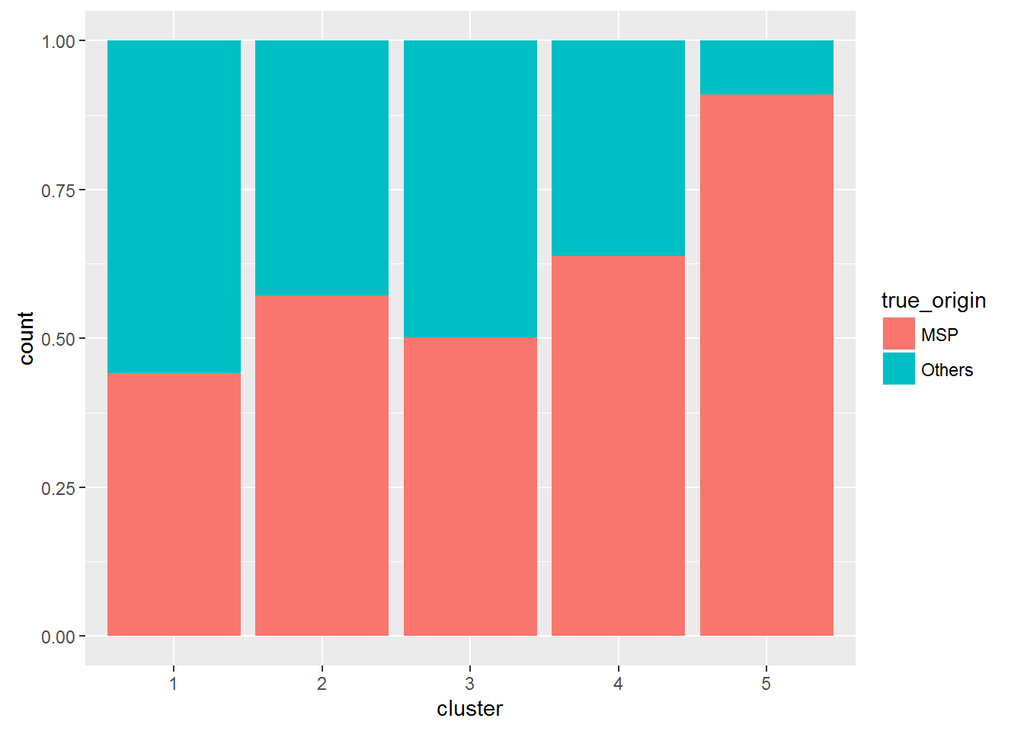

```r
ggplot(customer_data_bin,aes(x=cluster,fill=true_origin))+geom_bar(position = 'fill')
```

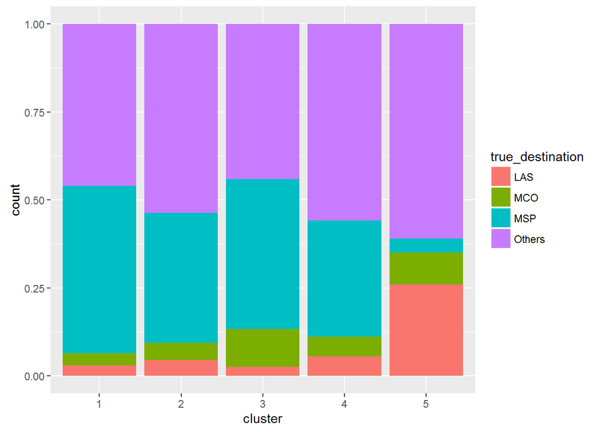

```r
ggplot(customer_data_bin,aes(x=cluster,fill=true_destination))+geom_bar(position = 'fill')
```

#### group and group size

**Cluster3 has distinctive pattern in terms of group and group size. Majority customers in Cluster3 have companies in trips and all other Clusters are dominated by single travellers.**

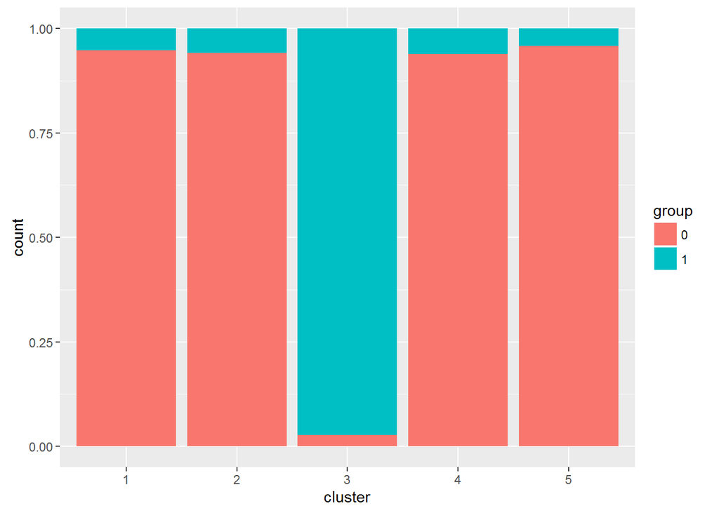

```r
ggplot(customer_data_cluster,aes(x=cluster,fill=group))+geom_bar(position = 'fill')
```

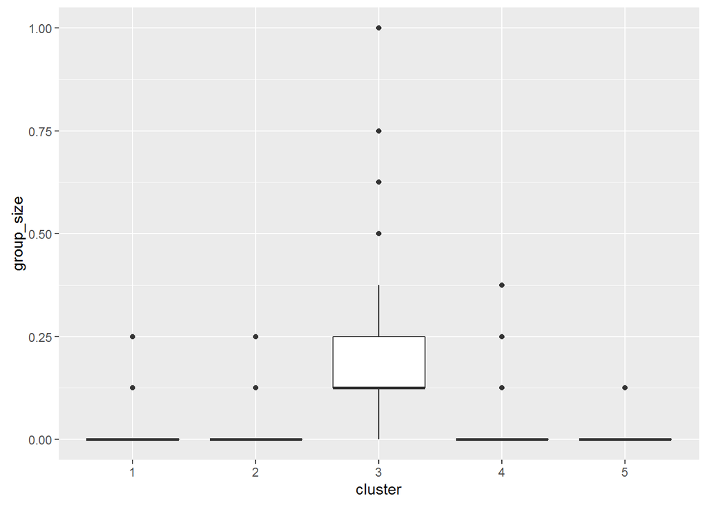

```r
ggplot(customer_data_cluster,aes(x=cluster,y=group_size))+geom_boxplot()
```

### Target variable

As the avg_amt is directly associated with the profit of Sun Country, I will use it as the target variable for predictive models.

### Spliting by clusters

```r
customer_data_fit1 <-
  customer_data_bin %>%
  filter(cluster == 1)

customer_data_fit2 <-
  customer_data_bin %>%
  filter(cluster == 2)

customer_data_fit3 <-
  customer_data_bin %>%
  filter(cluster == 3)

customer_data_fit4 <-
  customer_data_bin %>%
  filter(cluster == 4)

customer_data_fit5 <-
  customer_data_bin %>%
  filter(cluster == 5)
```

### Developing linear regression model for each cluster

```r
frmla <-  avg_amt ~ BookingChannel + UflyMemberStatus + age_group + round_trip + group_size + group + seasonality + days_pre_booked

#Cluster1
fit1 <- lm(frmla, data=customer_data_fit1[,2:12])
summary(fit1)
```

```
##
## Call:
## lm(formula = frmla, data = customer_data_fit1[, 2:12])
##
## Residuals:
##      Min       1Q   Median       3Q      Max
## -0.06687 -0.01950 -0.00223  0.01658  0.94425
##
## Coefficients:
##                                      Estimate Std. Error t value Pr(>|t|)
## (Intercept)                         1.179e-02  1.483e-02   0.795 0.426628
## BookingChannelOutside Booking       1.711e-02  8.545e-03   2.002 0.045369
## BookingChannelReservations Booking  5.626e-05  9.220e-03   0.006 0.995131
## BookingChannelSCA Website Booking   1.530e-02  8.732e-03   1.753 0.079757
## BookingChannelSY Vacation           2.446e-02  1.156e-02   2.116 0.034435
## BookingChannelTour Operator Portal -3.417e-02  9.111e-03  -3.750 0.000180
## UflyMemberStatusnon-ufly            1.467e-02  1.172e-02   1.252 0.210601
## UflyMemberStatusStandard            1.963e-02  1.186e-02   1.656 0.097823
## age_group18-24                     -2.819e-03  2.533e-03  -1.113 0.265820
## age_group25-34                      4.337e-03  2.154e-03   2.013 0.044170
## age_group35-54                      4.128e-03  2.530e-03   1.632 0.102841
## age_group55+                        3.885e-03  2.660e-03   1.460 0.144274
## round_trip1                         1.171e-02  4.723e-03   2.479 0.013237
## group_size                          1.440e-01  1.418e-01   1.015 0.310044
## group1                             -2.033e-02  1.843e-02  -1.103 0.269919
## seasonalityQ2                       9.689e-04  2.669e-03   0.363 0.716657
## seasonalityQ3                       8.007e-03  2.409e-03   3.324 0.000899
## seasonalityQ4                      -5.888e-04  2.662e-03  -0.221 0.824955
## days_pre_booked                    -2.028e-02  9.001e-03  -2.253 0.024329
##
## (Intercept)
## BookingChannelOutside Booking      *
## BookingChannelReservations Booking
## BookingChannelSCA Website Booking  .
## BookingChannelSY Vacation          *
## BookingChannelTour Operator Portal ***
## UflyMemberStatusnon-ufly
## UflyMemberStatusStandard           .
## age_group18-24
## age_group25-34                     *
## age_group35-54
## age_group55+
## round_trip1                        *
## group_size
## group1
## seasonalityQ2
## seasonalityQ3                      ***
## seasonalityQ4
## days_pre_booked                    *
## ---
## Signif. codes:  0 '***' 0.001 '**' 0.01 '*' 0.05 '.' 0.1 ' ' 1
##
## Residual standard error: 0.0349 on 2977 degrees of freedom
## Multiple R-squared:  0.09168,    Adjusted R-squared:  0.08618
## F-statistic: 16.69 on 18 and 2977 DF,  p-value: < 2.2e-16
```

```r
#Cluster2
fit2 <- lm(frmla, data=customer_data_fit2[,2:12])
summary(fit2)
```

```
##
## Call:
## lm(formula = frmla, data = customer_data_fit2[, 2:12])
##
## Residuals:
##      Min       1Q   Median       3Q      Max
## -0.07755 -0.02002 -0.00341  0.01332  0.42519
##
## Coefficients:
##                                      Estimate Std. Error t value Pr(>|t|)
## (Intercept)                         5.798e-02  1.009e-02   5.746 1.03e-08
## BookingChannelOutside Booking       1.869e-02  7.980e-03   2.342 0.019250
## BookingChannelReservations Booking  1.638e-02  8.399e-03   1.951 0.051215
## BookingChannelSCA Website Booking   1.761e-02  7.844e-03   2.245 0.024849
## BookingChannelSY Vacation           2.834e-02  9.522e-03   2.977 0.002942
## BookingChannelTour Operator Portal -3.647e-02  8.674e-03  -4.204 2.71e-05
## UflyMemberStatusnon-ufly           -2.248e-02  5.845e-03  -3.847 0.000123
## UflyMemberStatusStandard           -2.226e-02  5.920e-03  -3.760 0.000174
## age_group18-24                     -4.468e-03  2.881e-03  -1.551 0.121072
## age_group25-34                     -7.768e-05  2.824e-03  -0.028 0.978059
## age_group35-54                      1.816e-03  2.033e-03   0.893 0.371849
## age_group55+                        3.326e-04  2.805e-03   0.119 0.905629
## round_trip1                         6.240e-03  4.749e-03   1.314 0.188995
## group_size                         -1.049e-03  1.039e-01  -0.010 0.991943
## group1                             -1.318e-03  1.379e-02  -0.096 0.923878
## seasonalityQ2                       1.445e-03  2.108e-03   0.686 0.493021
## seasonalityQ3                       5.720e-03  2.396e-03   2.387 0.017047
## seasonalityQ4                      -5.505e-03  2.622e-03  -2.099 0.035882
## days_pre_booked                    -1.425e-02  7.888e-03  -1.807 0.070935
##
## (Intercept)                        ***
## BookingChannelOutside Booking      *
## BookingChannelReservations Booking .
## BookingChannelSCA Website Booking  *
## BookingChannelSY Vacation          **
## BookingChannelTour Operator Portal ***
## UflyMemberStatusnon-ufly           ***
## UflyMemberStatusStandard           ***
## age_group18-24
## age_group25-34
## age_group35-54
## age_group55+
## round_trip1
## group_size
## group1
## seasonalityQ2
## seasonalityQ3                      *
## seasonalityQ4                      *
## days_pre_booked                    .
## ---
## Signif. codes:  0 '***' 0.001 '**' 0.01 '*' 0.05 '.' 0.1 ' ' 1
##
## Residual standard error: 0.03102 on 2425 degrees of freedom
## Multiple R-squared:  0.09627,    Adjusted R-squared:  0.08956
## F-statistic: 14.35 on 18 and 2425 DF,  p-value: < 2.2e-16
```

```r
#Cluster3
fit3 <- lm(frmla, data=customer_data_fit3[,2:12])
summary(fit3)
```

```
##
## Call:
## lm(formula = frmla, data = customer_data_fit3[, 2:12])
##
## Residuals:
##       Min        1Q    Median        3Q       Max
## -0.080774 -0.016377 -0.000984  0.013629  0.173347
##
## Coefficients:
##                                     Estimate Std. Error t value Pr(>|t|)
## (Intercept)                         0.005893   0.022551   0.261 0.793944
## BookingChannelReservations Booking  0.013696   0.003773   3.630 0.000306
## BookingChannelSCA Website Booking   0.018977   0.004284   4.430 1.11e-05
## BookingChannelSY Vacation           0.042736   0.007842   5.450 7.22e-08
## BookingChannelTour Operator Portal -0.040337   0.005789  -6.968 8.02e-12
## UflyMemberStatusnon-ufly            0.008584   0.022038   0.390 0.697021
## UflyMemberStatusStandard            0.011855   0.022441   0.528 0.597474
## age_group18-24                      0.002242   0.003874   0.579 0.562927
## age_group25-34                      0.001493   0.004965   0.301 0.763764
## age_group35-54                      0.002094   0.003081   0.680 0.496930
## age_group55+                        0.013393   0.004356   3.075 0.002198
## round_trip1                        -0.008504   0.006940  -1.225 0.220895
## group_size                         -0.003639   0.008050  -0.452 0.651343
## group1                              0.024194   0.008169   2.961 0.003175
## seasonalityQ2                      -0.005138   0.003528  -1.456 0.145867
## seasonalityQ3                      -0.001579   0.003814  -0.414 0.678941
## seasonalityQ4                      -0.011419   0.003566  -3.202 0.001432
## days_pre_booked                     0.062757   0.008747   7.175 2.02e-12
##
## (Intercept)
## BookingChannelReservations Booking ***
## BookingChannelSCA Website Booking  ***
## BookingChannelSY Vacation          ***
## BookingChannelTour Operator Portal ***
## UflyMemberStatusnon-ufly
## UflyMemberStatusStandard
## age_group18-24
## age_group25-34
## age_group35-54
## age_group55+                       **
## round_trip1
## group_size
## group1                             **
## seasonalityQ2
## seasonalityQ3
## seasonalityQ4                      **
## days_pre_booked                    ***
## ---
## Signif. codes:  0 '***' 0.001 '**' 0.01 '*' 0.05 '.' 0.1 ' ' 1
##
## Residual standard error: 0.03058 on 638 degrees of freedom
## Multiple R-squared:  0.3549, Adjusted R-squared:  0.3377
## F-statistic: 20.65 on 17 and 638 DF,  p-value: < 2.2e-16
```

```r
#Cluster4
fit4 <- lm(frmla, data=customer_data_fit4[,2:12])
summary(fit4)
```

```
##
## Call:
## lm(formula = frmla, data = customer_data_fit4[, 2:12])
##
## Residuals:
##      Min       1Q   Median       3Q      Max
## -0.06842 -0.02151 -0.00444  0.01264  0.28557
##
## Coefficients:
##                                     Estimate Std. Error t value Pr(>|t|)
## (Intercept)                         0.057540   0.011062   5.202 2.13e-07
## BookingChannelOutside Booking       0.019884   0.008413   2.363 0.018183
## BookingChannelReservations Booking  0.029290   0.008767   3.341 0.000847
## BookingChannelSCA Website Booking   0.025669   0.008227   3.120 0.001829
## BookingChannelSY Vacation           0.040111   0.009447   4.246 2.25e-05
## BookingChannelTour Operator Portal -0.028606   0.009254  -3.091 0.002015
## UflyMemberStatusnon-ufly           -0.025326   0.007388  -3.428 0.000618
## UflyMemberStatusStandard           -0.028866   0.007415  -3.893 0.000102
## age_group18-24                     -0.005036   0.002981  -1.690 0.091246
## age_group25-34                     -0.006754   0.002814  -2.400 0.016465
## age_group35-54                      0.001067   0.003429   0.311 0.755612
## age_group55+                       -0.000704   0.002167  -0.325 0.745274
## round_trip1                         0.001423   0.004386   0.324 0.745642
## group_size                         -0.032557   0.056431  -0.577 0.564033
## group1                              0.005053   0.008174   0.618 0.536554
## seasonalityQ2                      -0.011491   0.002967  -3.873 0.000110
## seasonalityQ3                      -0.004959   0.002269  -2.185 0.028962
## seasonalityQ4                      -0.007997   0.001878  -4.259 2.13e-05
## days_pre_booked                     0.048471   0.006295   7.700 1.94e-14
##
## (Intercept)                        ***
## BookingChannelOutside Booking      *
## BookingChannelReservations Booking ***
## BookingChannelSCA Website Booking  **
## BookingChannelSY Vacation          ***
## BookingChannelTour Operator Portal **
## UflyMemberStatusnon-ufly           ***
## UflyMemberStatusStandard           ***
## age_group18-24                     .
## age_group25-34                     *
## age_group35-54
## age_group55+
## round_trip1
## group_size
## group1
## seasonalityQ2                      ***
## seasonalityQ3                      *
## seasonalityQ4                      ***
## days_pre_booked                    ***
## ---
## Signif. codes:  0 '***' 0.001 '**' 0.01 '*' 0.05 '.' 0.1 ' ' 1
##
## Residual standard error: 0.03262 on 2543 degrees of freedom
## Multiple R-squared:  0.1151, Adjusted R-squared:  0.1088
## F-statistic: 18.37 on 18 and 2543 DF,  p-value: < 2.2e-16
```

```r
#Cluster5
fit5 <- lm(frmla, data=customer_data_fit5[,2:12])
summary(fit5)
```

```
##
## Call:
## lm(formula = frmla, data = customer_data_fit5[, 2:12])
##
## Residuals:
##      Min       1Q   Median       3Q      Max
## -0.06996 -0.02566 -0.00250  0.01759  0.44644
##
## Coefficients: (1 not defined because of singularities)
##                                     Estimate Std. Error t value Pr(>|t|)
## (Intercept)                         0.026826   0.024826   1.081 0.280022
## BookingChannelOutside Booking       0.057242   0.023430   2.443 0.014646
## BookingChannelReservations Booking  0.064443   0.023759   2.712 0.006739
## BookingChannelSCA Website Booking   0.071087   0.023569   3.016 0.002593
## BookingChannelSY Vacation           0.070026   0.023709   2.954 0.003179
## BookingChannelTour Operator Portal  0.006442   0.023734   0.271 0.786106
## UflyMemberStatusnon-ufly           -0.027198   0.013548  -2.007 0.044834
## UflyMemberStatusStandard           -0.022155   0.013715  -1.615 0.106378
## age_group18-24                     -0.008801   0.004013  -2.193 0.028424
## age_group25-34                     -0.019247   0.004002  -4.810 1.62e-06
## age_group35-54                     -0.007080   0.002863  -2.473 0.013484
## age_group55+                       -0.007624   0.003487  -2.186 0.028899
## round_trip1                        -0.005980   0.006782  -0.882 0.378047
## group_size                         -0.044142   0.035929  -1.229 0.219375
## group1                                    NA         NA      NA       NA
## seasonalityQ2                      -0.011152   0.002864  -3.894 0.000102
## seasonalityQ3                      -0.012093   0.003976  -3.042 0.002383
## seasonalityQ4                      -0.004081   0.002609  -1.564 0.117933
## days_pre_booked                     0.013835   0.007827   1.768 0.077296
##
## (Intercept)
## BookingChannelOutside Booking      *
## BookingChannelReservations Booking **
## BookingChannelSCA Website Booking  **
## BookingChannelSY Vacation          **
## BookingChannelTour Operator Portal
## UflyMemberStatusnon-ufly           *
## UflyMemberStatusStandard
## age_group18-24                     *
## age_group25-34                     ***
## age_group35-54                     *
## age_group55+                       *
## round_trip1
## group_size
## group1
## seasonalityQ2                      ***
## seasonalityQ3                      **
## seasonalityQ4
## days_pre_booked                    .
## ---
## Signif. codes:  0 '***' 0.001 '**' 0.01 '*' 0.05 '.' 0.1 ' ' 1
##
## Residual standard error: 0.03969 on 1978 degrees of freedom
## Multiple R-squared:  0.1268, Adjusted R-squared:  0.1193
## F-statistic:  16.9 on 17 and 1978 DF,  p-value: < 2.2e-16
```

### Developing linear regression model for all data

```r
#All data
fit <- lm(frmla, data=customer_data_cluster[,2:12])
summary(fit)
```

```
##
## Call:
## lm(formula = frmla, data = customer_data_cluster[, 2:12])
##
## Residuals:
##      Min       1Q   Median       3Q      Max
## -0.07362 -0.02119 -0.00272  0.01470  0.95377
##
## Coefficients:
##                                      Estimate Std. Error t value Pr(>|t|)
## (Intercept)                         0.0514418  0.0064052   8.031 1.07e-15
## BookingChannelOutside Booking       0.0169241  0.0048441   3.494 0.000478
## BookingChannelReservations Booking  0.0207740  0.0050396   4.122 3.78e-05
## BookingChannelSCA Website Booking   0.0224659  0.0048439   4.638 3.56e-06
## BookingChannelSY Vacation           0.0312081  0.0053185   5.868 4.55e-09
## BookingChannelTour Operator Portal -0.0320347  0.0051416  -6.231 4.83e-10
## UflyMemberStatusnon-ufly           -0.0182267  0.0042102  -4.329 1.51e-05
## UflyMemberStatusStandard           -0.0178494  0.0042508  -4.199 2.70e-05
## age_group18-24                     -0.0042959  0.0014067  -3.054 0.002265
## age_group25-34                     -0.0029167  0.0012187  -2.393 0.016712
## age_group35-54                      0.0007083  0.0011060   0.640 0.521914
## age_group55+                        0.0009741  0.0011582   0.841 0.400336
## round_trip1                         0.0043471  0.0024025   1.809 0.070419
## group_size                          0.0230137  0.0074314   3.097 0.001961
## group1                             -0.0006913  0.0016953  -0.408 0.683465
## seasonalityQ2                      -0.0040907  0.0009691  -4.221 2.45e-05
## seasonalityQ3                      -0.0011892  0.0009683  -1.228 0.219438
## seasonalityQ4                      -0.0057316  0.0009470  -6.052 1.48e-09
## days_pre_booked                     0.0237744  0.0031833   7.469 8.75e-14
##
## (Intercept)                        ***
## BookingChannelOutside Booking      ***
## BookingChannelReservations Booking ***
## BookingChannelSCA Website Booking  ***
## BookingChannelSY Vacation          ***
## BookingChannelTour Operator Portal ***
## UflyMemberStatusnon-ufly           ***
## UflyMemberStatusStandard           ***
## age_group18-24                     **
## age_group25-34                     *
## age_group35-54
## age_group55+
## round_trip1                        .
## group_size                         **
## group1
## seasonalityQ2                      ***
## seasonalityQ3
## seasonalityQ4                      ***
## days_pre_booked                    ***
## ---
## Signif. codes:  0 '***' 0.001 '**' 0.01 '*' 0.05 '.' 0.1 ' ' 1
##
## Residual standard error: 0.03466 on 10635 degrees of freedom
## Multiple R-squared:  0.1045, Adjusted R-squared:  0.103
## F-statistic: 68.96 on 18 and 10635 DF,  p-value: < 2.2e-16
```

### Differences between clusters

**from the summary of regression models of each cluster, we can find the relationship between avg_amt and different variables are different among clusters.**

#### Predictors with significant relationship with response variables

- **round trip and avg_amt** round trip has a significant possitive relationship with avg_amt in Cluster1, while such relationship doesn’t exist in other clusters.
- **group and avg_amt** group has a significant possitive relationship with avg_amt in Cluster3, while no significant relationship in other clusters.

#### The change in response variables with unit change in predictors

- **The coefficient of the same variable can be very different in different clusters which means for unit change in the variable, the change in avg_amt is very different.**

#### The fitting performance of the model

- **The regression model developed using all data has a R squre of 10%, whereas models developed for each cluster whose data points share more similarities have R squares similar or higher(33% for Cluster3).**

**In conclusion, understanding hidden structures of data through exploratory method such as clustering before developing models can generally improve the exploratory performance of the models. Without understanding the structure inside data and simply using one model for all observations may generate suspecious result.**

## Objective Revisisted

Recall that your task is to analyze the data for potential insight to inform and answer the following questions. You should have been computing results, accompanied by exposistion, in support of answers these questions throughout. However, spend the rest of this document bringing everything you learned together to explicitly address these questions. You should also ensure that you actually discuss and characterize the various segments that you discovered.

1. How usable is the data you received from the client (Sun Country)? Given the state of the data, what steps would you take to make it usable and useful – for the initial assigned project and for Sun Country longer term?

#### The usability of the original data:

- **Missing data**: the original data contains missing values for UflyRewardsNumber, UflyMemberStatus etc. Keeping the missing values will make the dataset not valid for some analytic algorithms, or lose information(e.g.NA UflyMemberStatus is actually non-member).
- **Inconsistent data**: the original data also contains many faulty data such as Age above 120 and city codes in BookingChannel. Keeping such errors will create many distractions and undermine the quality of analysis.
- **Granularity**: the original data is transaction data with each row representing a combination of one book, one flight and one traveler. However for most analysis such as this one, obeservations based on trips instead of flights can provide better business insight.**
- **Features**: relating to the granularity of the original data, all features in the original data are associated with flights rather than trips thus also contains less business insight.**
- **Scale**: numerical variables in the original dataset is in different scales which will make result of some analytic algorithms dominated by variables of larger scales and thus become invalid.**

#### Steps to make the data usable and useful

- **Cleaning missing data**: missing data in UflyRewardsNumber and UflyMemberStatus are replaced with best estimation such as replace NA in UflyRewardsNumber with 0 and missing values in UflyMemberStatus with “non-members”.
- **Cleaning inconsistent data**: faulty data are removed with the entire row or replaced with best estimation.**
- **Transforming granularity**: the data was transformed from flight based into trip and traveler based.**
- **Feature generation**: features associated each trip such as origin, destination, Oneway or RoundTrip was generated. other useful features such as Days Booked in Advance and Group Size was also generated.**
- **Data discretization**: Age was converted into categorical Age_group assuming travellers in each group are similar to each other while different with travellers in other groups. ServiceStartDate of each trip was converted into categorical Seasonality variable assuming trips starting in the same quarter are similar to each other while different with trips in other quarters.**
- **Normalization**: numerical variables were normalized using Min-Max method to offset the impact of scale in order to make them usable for many analytic algorithms such as k-means in this project.**
2. Based on what you see in the data, how many different ways can you view the information to paint a picture of different customer segments? Which ways offer Sun Country the most insights? How could the insights be used?

#### How the insights from visualization can be used:

- Since the objective of this project is to find customer segments and understand their respective profiles and flying patterns in order to support product development, digital marketing or other business decisions of Sun Country. Insights from visualization is can be used for:
- **providing easy understanding business insights for business managers.**
- **serving as an exploratory step and preparing for supervised learnings or other analytical projects.**
- **evaluating the performance of the segmentation.**

#### The ways that can provide the most insights:

- **Dimensionality**: as most variables are categorical, it is not suitable to use scatter plot with colors and shapes to add more dimensions including cluster. Plotting each nominal variables against different clusters may lose some information regarding the relationship among variables but is clear and contains the most information.
- **Types of graph**: bar plot is the best choice to visualize two categorical data talked above.
- **Units**: using proportion instead of counts for bar plots of each categorical data against clusters can easily visualize the difference between clusters without the impact of the size of each cluster.The lost information of cluster sizes can be plotted separately.
3. How would you visualize and present the insights you found for the client? What will you do in order to show Warnken and Vaughan how the insights you derived connect to their business objectives?

   My visualization and presentation of insights can be found in the visualization part. I tried to convert the data generated by clustering into business insight that may help Warnken and Vaughan get more knowledge connect to their business objective in my communication and provide some suggestions derived from insights to show how those insights can help decision making.
4. Discuss: how much power lies in simply understanding and exploring your data? Consider the downside of focusing too much on fancy models.

   **open-mindedly exploreing, and visualizing data helps analysts to reveal the secrets beneath data and gain fresh, unknown-unknown insights about the data. Using this project as an example, we are able to achieve below tasks through exploration.**
- **Data preparation:** through summarization and other exploratory activities, we can detect missing data, anomalies and outliers and clean the data which is essential for any data analysis. Models without data of high quality cannot provide high-quality result.
- **Uncover underlying structure:** by clusering and visualization of clusters of customers, we can have a better understanding of the structure of customers. It can also serve as a starting point for detailed analysis of each clusters.Without understanding the structure inside data and simply using one model for all observations may generate suspecious result.
- **Determine optimal parameter settings**: in this project, I plotted elbow curve and silhouette curve to find the optimal number of k for clustering model. Many other models also need analysts to input parameters and the performances of the models highly rely on those parameters.
- **Extract important variables:** some variables were found not very useful for clustering in this project through exploration. In other cases, fancy models cannot select important variables automatically.